# Hotelling’s T<sup>2</sup> and Multivariate Analysis Of VAriance

# Multivariate group comparisons

- Univariate: t-tests, ANOVA
- Multivariate: Hotelling’s T**²**, MANOVA
  - Generalizes the t-test, ANOVA to multivariate responses
  - Versions for two-sample, one-sample, paired designs
  - Omnibus test for 3 or more groups

# But why?

- Prevention of inflated Type I error rate
- Accounting for lack of independence of tests
- Better detection of multivariate response

## Controlling Type I error

- Same as with univariate ANOVA
  - With 2 groups and 1 response variable we get 1 p-value
  - With 3 groups and 1 response variable we get 3 p-values
  - With 3 groups and 2 response variables we get 6 p-values
- If instead we do an omnibus multivariate test we get 1 p-value

# But why?

- Prevention of inflated Type I error rate
- Accounting for lack of independence of tests
- Better detection of multivariate response

## We adjust for non-independent tests

- No such thing as a “career-wise” error rate
  - Different data sets, different experiments are independent, no correction
- Measures of different variables on the same subjects are not independent
  - Correlation between them ≠ 0
- We correct for multiple p-values when tests are not independent

# But why?

- Prevention of inflated Type I error rate
- Accounting for lack of independence of tests
- Better detection of multivariate response

## Multivariate patterns require multivariate analysis

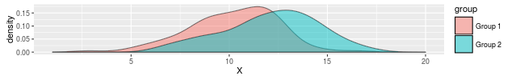

*A lot of overlap on x*

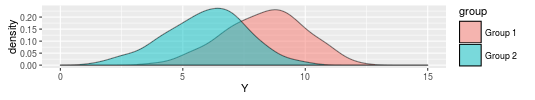

*A lot of overlap on y*

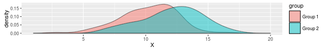

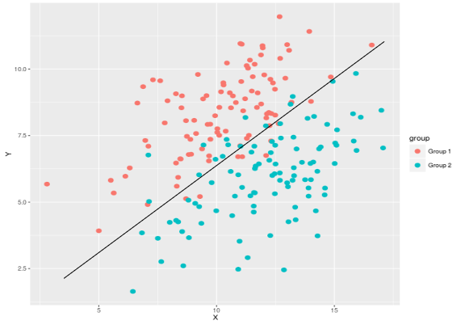

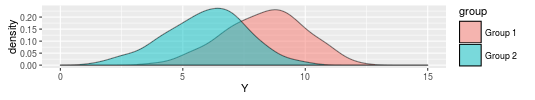

Less overlap on x and y together

# Testing multivariate hypotheses

- Comparing two or more groups measured on two or more response variables
  - Vector of means on every variable for each group = **centroids**
- Approaches:
  - Use a latent variable as response, compare groups with a univariate analysis
  - Use a multivariate version of t or ANOVA

# Multivariate versions of group comparisons

- Hotelling’s T<sup>2</sup>
- Multivariate ANOVA (MANOVA)

## Two-sample Hotelling’s T<sup>2</sup>

- Comparison of two independent groups
  - Compare the centroids
  - Use a pooled estimate of the covariace matrix
- Has the same assumptions of a univariate t-test, plus one
  - Normality, HOV
  - Equality of covariance matrices

## Two of the three irises

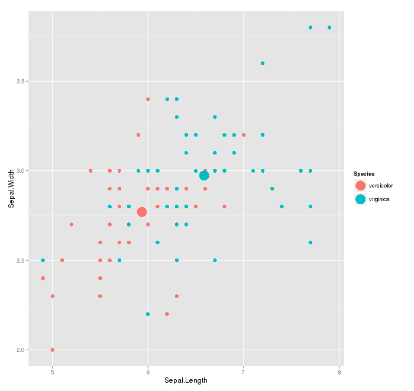

*Two variables*

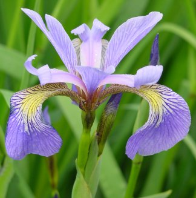

*Iris versicolor*

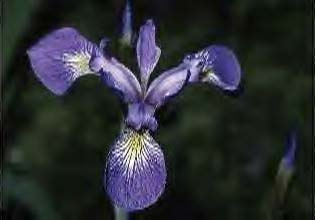

*Iris virginica*

Are the differences clearer when both variables are considered at once?

## Comparison: t, T<sup>2</sup>

*The test statistic for a two sample t-test*

$$t =\frac{(\bar{x}_1 - \bar{x}_2)}{s_{\bar{x},p}} = \frac{d}{s_{\bar{x},p}}$$

*Squaring t, writing pooled standard error as pooled variance multiplied by group sample sizes:*

$$t^2= \frac{d^2}{s^2_p\frac{(n_1+n_2)}{n_1n_2}}$$
*which can be re-written as:*

$$t^2=\frac{n_1n_2}{n_1+n_2}d(s^2_p)^{-1}d$$

*Vector of differences between means of p variables:*

$$\textbf{d}=\begin{bmatrix}
\bar{x}_{1,1}-\bar{x}_{2,1} \\
\bar{x}_{1,2}-\bar{x}_{2,2} \\
... \\
\bar{x}_{1,p}-\bar{x}_{2,p} \\
\end{bmatrix}$$

*Hotelling’s T<sup>2</sup>*

$$T^2=\frac{n_1n_2}{n_1+n_2}\textbf{dS}^{-1}\textbf{d}'$$
*just like t<sup>2</sup>, but for more than one variable*

## Pooled covariance matrix

$$\frac{\text{Versicolor SSCP + Virginica SSCP}}{n_1+n_2-2}=\text{Pooled S matrix}$$

$$\frac{
\begin{array}{cc}
& \text{SL} \quad \qquad \text{SW} \\
\begin{array}{r}
\text{SL} \\
\text{SW}
\end{array} &
\left[
\begin{array}{cc}
13.0552 & 4.174\\
4.1740 & 4.825\\
\end{array}
\right]
\end{array} + \begin{array}{cc}
& \text{SL} \qquad \quad \text{SW} \\
\begin{array}{r}
\text{SL} \\
\text{SW}
\end{array} &
\left[
\begin{array}{cc}
19.8128 & 4.5944\\
4.5944 & 5.0962\\
\end{array}
\right]
\end{array}}{50 + 50 - 2} =
\begin{array}{cc}
& \text{SL} \qquad \quad \text{SW} \\
\begin{array}{r}
\text{SL} \\
\text{SW}
\end{array} &
\left[
\begin{array}{cc}
0.33539 & 0.08947\\
0.08947 & 0.10124\\
\end{array}
\right]
\end{array}$$

Hotelling’s T<sup>2</sup> and MANOVA assume equal covariance matrices so that **S** is an estimate that pertains to both groups

## Test statistic

$T^2=\frac{n_1n_2}{n_1+n_2}\textbf{dS}^{-1}\textbf{d}^{′}$

Inverse of **S** matrix

$\textbf{S}^{-1} = \begin{array}{cc} &\text{SL} \qquad \quad \text{SW} \\ \begin{array}{r} \text{SL} \\ \text{SW} \end{array} & \left[ \begin{array}{cc} 3.90 & -3.45\\ -3.45 & 12.93\\ \end{array} \right] \end{array}$

Differences between means:

$\textbf{d} = \begin{array}{cc} & \text{SL} \quad \quad \text{SW} \\ \begin{array}{r} \\ \end{array} & \left[ \begin{array}{cc} -0.652 & -0.204\\ \end{array} \right] \end{array}$

$\textbf{dS}^{-1}\textbf{d}^{′} = \begin{array}{r} \left[ \begin{array}{cc} -0.652 & -0.204\\ \end{array} \right] \end{array} \begin{array}{r} \left[ \begin{array}{cc} 3.90 & -3.45\\ -3.45 & 12.93\\ \end{array} \right] \end{array} \begin{array}{r} \left[ \begin{array}{cc} -0.652 \\ -0.204\\ \end{array} \right] \end{array}=1.28$  
$T^2=\frac{50\times50}{50+50}\times1.28=31.97$

## Tested with an F approximation

$F=\frac{n_1+n_2-p-1}{(n_1+n_2-2)p}T^2=\frac{97}{196}31.97=15.824$

d.f.<sub>numerator</sub> = p = 2  
d.f.<sub>deniminator</sub> = N-p-1 = 97  
p < 0.001

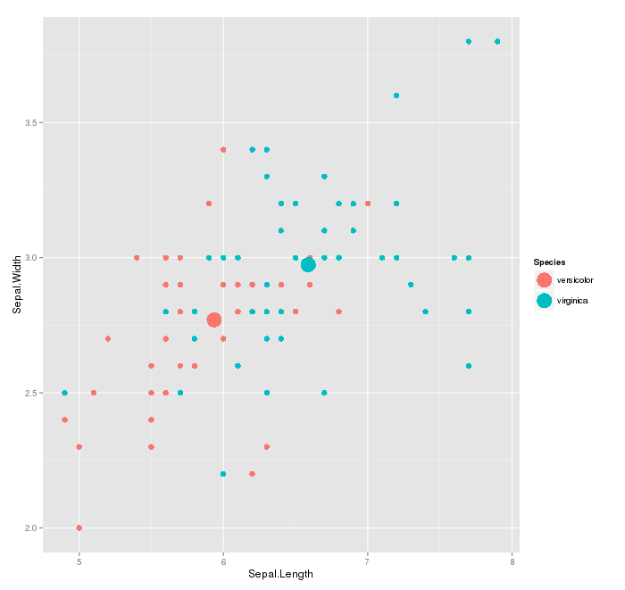

## Equality of covariance matrices assumption

- All three have the same centroids
  - Thus, same differences
- Should all have the same p-value?
- Should a pooled estimate be good for all three?

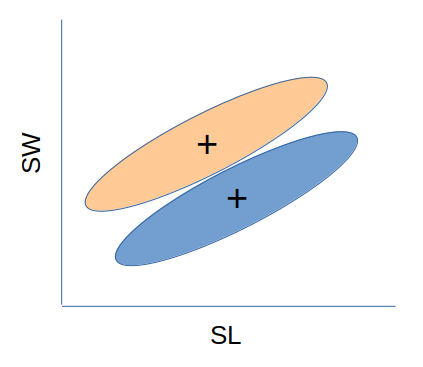

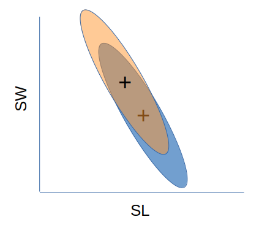

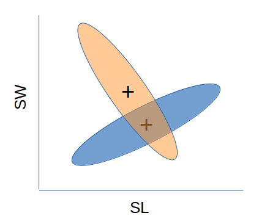

# Multivariate versions of group comparisons

- Hotelling’s T<sup>2</sup>
- Multivariate ANOVA (MANOVA)

## Two or more groups

- Like ANOVA, MANOVA starts with an omnibus test
- ANOVA null hypothesis: $H_0:\mu_1=\mu_2\dots=\mu_p$, one or more differences → reject $H_0$
- Manova generalizes this to:

$$H_0:\begin{array}{r}
\left[
\begin{array}{cc}
\mu_{1,1} \\ \mu_{1,2}\\ \dots \\ \mu_{1,p}\\
\end{array}
\right]
\end{array} =
\begin{array}{r}
\left[
\begin{array}{cc}
\mu_{2,1} \\ \mu_{2,2}\\ \dots \\ \mu_{2,p}\\
\end{array}
\right]
\end{array}=\dots=
\begin{array}{r}
\left[
\begin{array}{cc}
\mu_{k,1} \\ \mu_{k,2}\\ \dots \\ \mu_{k,p}\\
\end{array}
\right]
\end{array}$$

- In other words, $H_0$ is that the mean of every variable is the same for every group
- Reject $H_0$ if any pair of groups is different on any variable

## ANOVA, MANOVA

| ANOVA | MANOVA |
| --- | --- |
| Differences among 2 or more means for a single dependent variable | Differences between 2 or more **centroids** for 2 or more dependent variables |
| Compare variance explained by the model to variance unexplained | Compare multivariate variance *unexplained* to *total* multivariate variance |

## Three species, two variables

- MANOVA partitions total variation in SL, SW between:
  - Explained
  - Unexplained

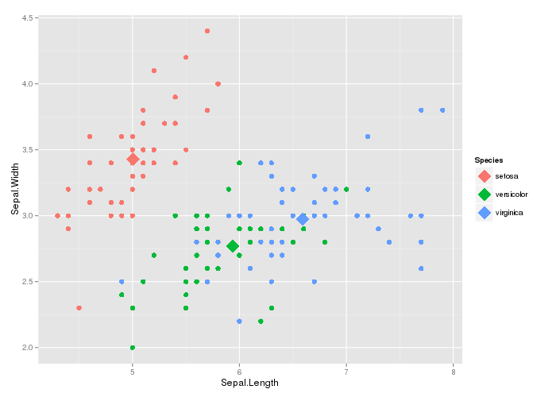

- Big differences between centroids = large amount of explained variation
- Ratio of unexplained/total variation is the test statistic

## W and B

- Within (W) = unexplained, random variation within groups, around centroids
- Between (B) = variability between group centroids
  - Differences between group means and grand means for each variable
  - Explained variation = variation due to fixed effects of treatments applied to groups
- Total (T) = sum of W and B

## Calculating W

1. Calculate a matrix of within-group residuals

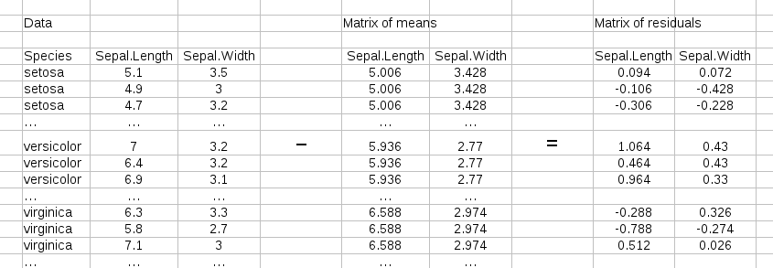

**R** = data values - group means

## Within-group SSCP for each species

2. **RR′** for each group

Setosa

$\begin{array}{cc} &\text{SL} \qquad \quad \text{SW} \\ \begin{array}{r} \text{SL} \\ \text{SW} \end{array} & \left[ \begin{array}{cc} 6.09 & 4.86\\ 4.86 & 7.04\\ \end{array} \right] \end{array}$

Versicolor

$\begin{array}{cc} &\text{SL} \qquad \quad \text{SW} \\ \begin{array}{r} \text{SL} \\ \text{SW} \end{array} & \left[ \begin{array}{cc} 13.06 & 4.17\\ 4.17 & 4.83\\ \end{array} \right] \end{array}$

Virginica

$\begin{array}{cc} &\text{SL} \qquad \quad \text{SW} \\ \begin{array}{r} \text{SL} \\ \text{SW} \end{array} & \left[ \begin{array}{cc} 19.81 & 4.59\\ 4.59 & 5.10\\ \end{array} \right] \end{array}$

3. Sum these to get W

## Calculating B

1. Calculate differences between group means and grand means

$\begin{array}{cc} &\text{SL} \qquad \quad \text{SW} \\ \begin{array}{r} \text{setosa} \\ \text{versicolor} \\ \text{virginica} \end{array} & \left[ \begin{array}{cc} 5.01 & 3.43\\ 5.94 & 2.77\\ 6.59 & 2.97\\ \end{array} \right] \end{array}- \begin{array}{cc} & \text{SL} \quad \quad \text{SW} \\ \begin{array}{r} \\ \end{array} & \left[ \begin{array}{cc} 5.84 & 3.06\\ 5.84 & 3.06\\ 5.84 & 3.06\\ \end{array} \right] \end{array}= \begin{array}{cc} & \text{SL} \quad \quad \text{SW} \\ \begin{array}{r} \\ \end{array} & \left[ \begin{array}{cc} -0.84 & 0.37\\ 0.09 & -0.29\\ 0.74 & -0.08\\ \end{array} \right] \end{array}$

2. Calculate n**RR′**

$\textbf{B}=50\times \begin{array}{cc} &\text{setosa} \quad \text{versicolor} \quad \text{virginica} \\ \begin{array}{r} \text{SL} \\ \text{SW} \end{array} & \left[ \begin{array}{cc} -0.84 & 0.09 & 0.74\\ 0.37 & -0.29 & -0.08\\ \end{array} \right] \end{array} \times \begin{array}{cc} &\text{SL} \qquad \quad \text{SW} \\ \begin{array}{r} \text{setosa} \\ \text{versicolor} \\ \text{virginica} \end{array} & \left[ \begin{array}{cc} -0.84 & 0.37\\ 0.09 & -0.29\\ 0.74 & -0.08\\ \end{array} \right] \end{array}= \begin{array}{cc} &\text{SL} \qquad \quad \text{SW} \\ \begin{array}{r} \text{SL} \\ \text{SW} \end{array} & \left[ \begin{array}{cc} 63.2 & -19.9\\ -19.9 & 11.3\\ \end{array} \right] \end{array}$

There are negative covariances in B, but not W, can you see why?

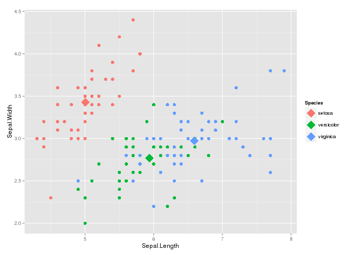

## Within, between, total

$$\text{Within (W):}\begin{array}{cc}
&\text{SL} \qquad \quad \text{SW} \\
\begin{array}{r}
\text{SL} \\
\text{SW}
\end{array} &
\left[
\begin{array}{cc}
38.96 & 13.63\\
13.63 & 16.96\\
\end{array}
\right]
\end{array}$$

$$\text{Between (B):}\begin{array}{cc}
&\text{SL} \qquad \quad \text{SW} \\
\begin{array}{r}
\text{SL} \\
\text{SW}
\end{array} &
\left[
\begin{array}{cc}
63.2 & -19.9\\
-19.9 & 11.3\\
\end{array}
\right]
\end{array}$$

$$\text{Total (T):}\begin{array}{cc}
&\text{SL} \qquad \quad \text{SW} \\
\begin{array}{r}
\text{SL} \\
\text{SW}
\end{array} &
\left[
\begin{array}{cc}
102.17 & -6.32\\
-6.32 & 28.31\\
\end{array}
\right]
\end{array}$$

$$|W| = 38.96 \times 16.96 - 13.63^2 = 474.99$$

$$|T| = 102.17 \times 28.31 - (-6.32)^2 = 2852.09$$

## Multivariate test statistic

$\Lambda=\frac{|W|}{|B+W|}=\frac{|W|}{|T|}$ ← Wilk’s lambda

$|W|$ = determinant of within-group SSCP

$|B+W|=|T|$ = determinant of total SSCP

Remember, determinants of SSCP matrices are multivariate measures of variance

## And, the test

$\Lambda=\frac{|W|}{|T|}=\frac{474.99}{2852.09}=0.166$

Bartlett’s $\chi^2$ approximation: $\chi^2=-[(N-1)-\frac{p+k}{2}]ln\Lambda$

$p_{\chi^2,df=2\times2}<0.001$

## Other multivariate test statistics

- Four commonly in use
  - Wilk’s lambda, Pillai’s trace, Hotelling-Lawley trace, Roy’s maximum root
- If design is balanced, all assumptions are met, they give nearly identical results
- Some are better than others with unbalanced designs, violated assumptions

## Pillai’s trace

- R’s default multivariate test statistic
- V=tr(BT<sup>-1</sup>)
  - tr = trace = sum of diagonal elements
- Significance tested with approximate F
- Better than Wilks when MV assumptions violated

$$\textbf{T}^{-1}:\begin{array}{cc}
&\text{SL} \qquad \quad \text{SW} \\
\begin{array}{r}
\text{SL} \\
\text{SW}
\end{array} &
\left[
\begin{array}{cc}
0.0099 & 0.0022\\
0.0022 & 0.0358\\
\end{array}
\right]
\end{array}$$

$$\textbf{B}:\begin{array}{cc}
&\text{SL} \qquad \quad \text{SW} \\
\begin{array}{r}
\text{SL} \\
\text{SW}
\end{array} &
\left[
\begin{array}{cc}
63.2 & -19.9\\
-19.9 & 11.3\\
\end{array}
\right]
\end{array}$$

$$\textbf{BT}^{-1}:\begin{array}{cc}
&\text{SL} \qquad \quad \text{SW} \\
\begin{array}{r}
\text{SL} \\
\text{SW}
\end{array} &
\left[
\begin{array}{cc}
0.5831 & -0.5746\\
-0.1729 & 0.3622\\
\end{array}
\right]
\end{array}$$

$$v=0.5831+0.3622=0.9453$$

## Hotelling and Roy

- Hotelling-Lawley trace = trace of **W**<sup>-1</sup>**B**
  - Generalization of T<sup>2</sup> to two or more groups
- Roy’s maximum root = the eigenvalue for the best discriminant function
  - Tends to be over-powered, not recommended

# Interpreting MANOVA

- A significant MANOVA indicates at least one pair of groups are different on at least one variable
  - Often more than two groups
  - Often more than one variable
  - Combinations of variables may be important
- Need post-hoc procedures to determine:
  - Which groups are different
  - Which variables, combinations of variables, are responsible

# Using MANOVA sensibly - power

- Many more parameters have to be estimated in a MANOVA than in a one-way ANOVA
- Reduces statistical power and precision
  - Power = probability of rejecting a false null
  - Precision = size of standard errors, confidence intervals
- It’s unwise to include response variables just because you can
  - Pick variables because they are interesting, not just because they are there

## Three variables separately

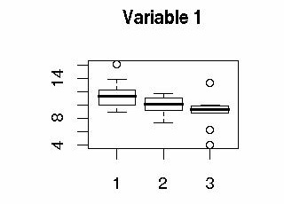

F = 4.09, df = 2,27, p = 0.02

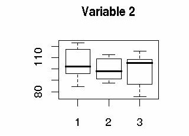

F = 0.49, df = 2,27, p = 0.62

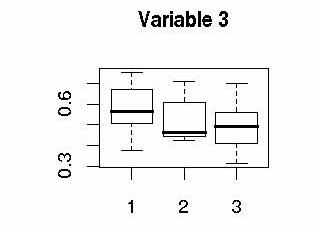

F = 1.62, df = 2,27, p = 0.22

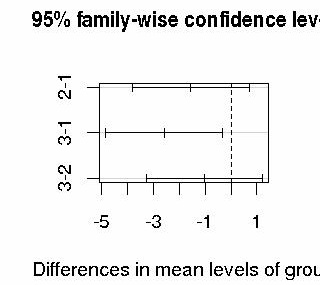

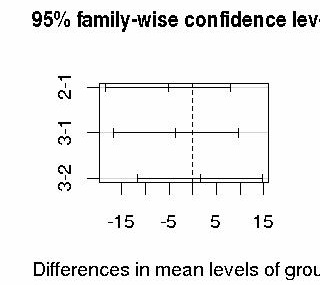

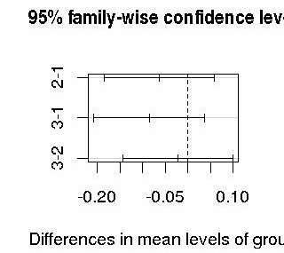

## Same data as MANOVA

Wilks = 0.634, F = 2.13, df = 6,50, p = 0.06

Pillai = 0.371, F = 1.97, df = 6,52, p = 0.08

Lawley-Hotelling = 0.57, F = 2.27, df = 6,48, p = 0.052

- Can’t detect the difference in variable 1
- Tolerable if all three variables are important, and need to be tested
- Not good if V1 was important and V2, V3 were thrown in just to see

# One-sample design

- With t-tests we can:
  - Compare means of independent samples = two-sample t-test
  - Compare means of paired samples = paired t-test
  - Compare means to a hypothetical value = one-sample t-test
- Hotelling’s T<sup>2</sup> and MANOVA on two groups are equivalent to two-sample t-test
- Can also do a one-sample or paired analysis

## Sexual size dimorphism in birds

- M/F birds often differ in size
- Some species aren’t different, some are “reverse” dimorphic
- Which sex is bigger generally?

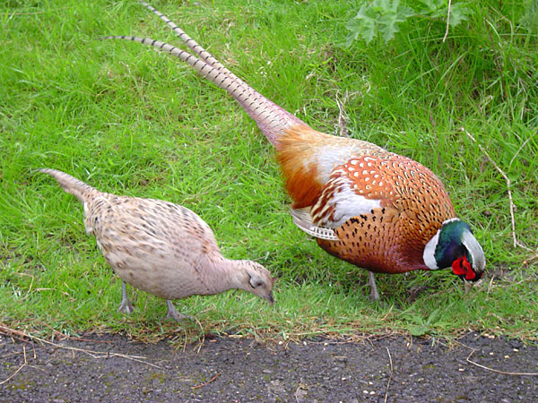

- Pairing: M/F for each species
  - Variables: log of mass, wing span, tarsus length, bill depth, tail length
  - Subtract F mean from M mean for each variable
  - Centroid tested against a vector of 0’s

## Calculate differences

| English_name | M_lmass | M_wing | M_tarsus | M_bill | M_tail |
| --- | --- | --- | --- | --- | --- |
| Plain Chachalaca | 6.3699 | 210.0 | 59.3 | 23.3 | 233.8 |
| Australian Brush-turkey | 7.8038 | 320.7 | 123.3 | 39.3 | 270.2 |
| See-see Partridge | 5.3230 | 136.0 | 34.4 | 11.9 | 55.5 |
| Chukar | 6.2841 | 168.0 | 46.8 | 15.2 | 82.3 |
| Red-legged Partridge | 6.2461 | 165.0 | 44.5 | 13.9 | 93.2 |
| Black Francolin | 6.1803 | 177.0 | 57.0 | 28.6 | 92.3 |
| … | … | … | … | … | … |

**-**

| F_lmass | F_wing | F_tarsus | F_bill | F_tail |
| --- | --- | --- | --- | --- |
| 6.2953 | 200 | 56.6 | 21.7 | 223.1 |
| 7.7007 | 307 | 111.2 | 36.2 | 261.7 |
| 5.2133 | 130 | 31.6 | 11.1 | 56.0 |
| 6.2166 | 154 | 44.1 | 14.3 | 78.9 |
| 6.0845 | 157 | 41.4 | 13.3 | 84.4 |
| 6.0521 | 167 | 52.4 | 26.6 | 88.3 |
| … | … | … | … | … |

**=**

[output not shown]

## Tested with an “intercept only” MANOVA

- With no predictors, intercept is the mean of response
  - Mean of differences, in this case
- Intercepts are tested against 0
- In a MANOVA, intercept-only model tests if all the mean differences are equal 0
  - Since the differences are from paired data this is a paired MANOVA
  - If we use Hotelling-Lawley it’s equivalent to a paired T<sup>2</sup>

## Interpretation

| Variable | Mean diffs. |
| --- | --- |
| log.mass | 0.05 |
| wing | 4.85 |
| tarsus | 1.00 |
| bill | 1.13 |
| tail | 4.84 |

## How big and consistent are the differences?

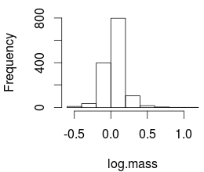

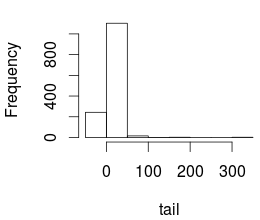

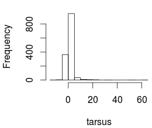

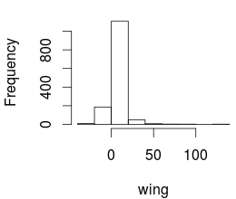

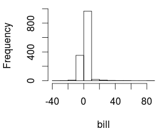

# Wrapup

- This week:
  - Learn to conduct the various types of Hotelling T<sup>2</sup> and MANOVA
- Next week:
  - Learn how to do post-hoc procedures after a significant MANOVA